# numpy数组处理图像问题练习

提示：如何读取图片和展示图片？ （1）读取图片 import matplotlib.pyplot as plt data = plt.imread("C:/test.jpg") # 需要图片路径C:/test.jpg （2）展示图片 plt.imshow(data, cmap='gray') # 需要图片的数组data， 查看灰度图需要加cmap='gray'参数，查看原图不需要。

===========练习============ 注意：一张图片等于一个数组，像素就等于数组中每个具体的值

1. （数组属性）读取并展示 outdoor.jpg ，查看图片数组的行列数 ，图片数组的像素数量，图片数组的最大、最小像素值。 若像素值值域在【0-1】之间，则变为0-255之间，否则不用处理。0表示黑色，255白色。
2. （数组切片）读取到的图片数组是RGB彩色三通道（也就是三个维度），通道维度为在第三维。分别提取R、G、B三个通道的数组，并展示这三个数组对应的图片
3. （数组切片）截取图片数组中你感兴趣的部分内容,随意截取
4. （数组计算）将原始图片转化为灰度图片并查看转化效果， 转换方法为：L = R *0.2989 + G* 0.587+ B * 0.114 ，以图片方式展示数组L即可
5. （数组筛选和计算）将上面的灰度图转为黑白二值图图并查看转化效果， 方法为：设定任一个阈值k【比如100】，小于k的像素值全部设置为0，大于等于100的值全部设置为255
6. （数组合并、重复）将图片数组【横向】、【纵向】、【每个值】分别重复3次，并展示对应图片
7. （数组维度调换）将图片数组做上下颠倒、左右颠倒变换，并展示对应图片 8.（数组计算）将图片变亮，可以通过对数变换实现，根据公式：y = b + a*np.log(x+1)去计算，并把计算结果大于255的值全部统一为255。 其中b为常数，a为系数，x为图像数组，a,b值可以自己指定。y即为新的数组。
8. （数组保存）把变亮的图片数组保存为.npy文件
9. 把原始图像数组处理成九宫格图像数组，即以原始图像数组为基础，分割成9个大小差不多的数组，每个小数组以空白隔开， 最后输出一个新的数组，这个数组打印出来是九宫格的形式。

```python
# 1. （数组属性）读取并展示 outdoor.jpg ，查看图片数组的行列数、维数 ，图片数组的像素数量，
# 图片数组的最大、最小像素值。若像素值值域在【0-1】之间，则变为0-255之间，否则不用处理。0表示黑色，255白色
import numpy as np
import matplotlib.pyplot as plt
img = plt.imread('./data/outdoor.jpg')  # 读取图片
img.shape
img.size
img.max() # np.max(img)
img.min() # np.min(img)
```

```
0
```

```python
# 若像素值值域在【0-1】之间，则变为0-255之间
if img.max()==1:
    img = np.array(img*255, dtype=np.uint8) # plt绘图的数据类型一定是int
img.max()
```

```
238
```

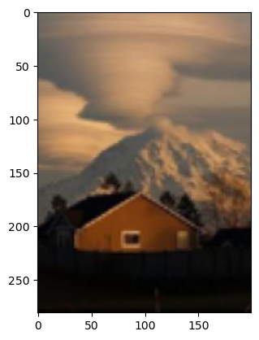

```python
# 3. （数组切片）截取图片数组中你感兴趣的部分内容,随意截取
plt.imshow(img[100:400, 200:400, :])
```

```
(381, 500)
```

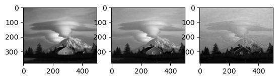

```python
# 2. （数组切片）读取到的图片数组是RGB彩色三通道（也就是第三个维度），通道维度为在第三维。
# 分别提取R、G、B三个通道的数组，并展示这三个数组对应的图片
R = img[:,:,0] # 第三个维度的第0个
G = img[:,:,1] # 第三个维度的第1个
B = img[:,:,2] # 第三个维度的第2个
plt.subplot(131)
plt.imshow(R)
plt.subplot(132) # 画三个图
plt.imshow(G)
plt.subplot(133)
plt.imshow(B)
B.shape
```

```
(381, 500)
```

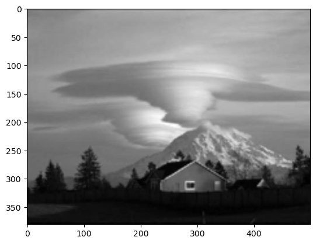

```python
# 4. （数组计算）将原始图片转化为灰度图片并查看转化效果，
# 转换方法为：L = R * 0.2989 + G * 0.587+ B * 0.114 ，以图片方式展示数组L即可
L = R * 0.2989 + G * 0.587+ B * 0.114
plt.imshow(L, cmap='gray')  # 查看灰度图要加cmap='gray'参数
L.shape
```

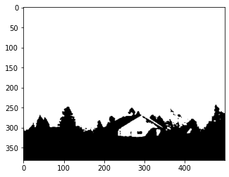

```python
# 5. （数组筛选和计算）将上面的灰度图转为黑白二值图图并查看转化效果，
# 方法为：设定任一个阈值k【比如100】，小于k的像素值全部设置为0,大于阈值的全部设置为255
L = R * 0.2989 + G * 0.587+ B * 0.114
K = 60
# L[L<K] = 0
# L[L>=K] = 255
L = np.where(L<K, 0, 255)
plt.imshow(L, cmap='gray')
```

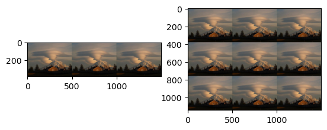

```python
# 6. （数组合并）将图片数组【横向】、【纵向】、【每个值】分别重复3次，并展示对应图片。
himg = np.hstack((img, img, img)) # 横向
vimg = np.vstack((himg, himg, himg)) # 纵向
plt.subplot(121)
plt.imshow(himg)
plt.subplot(122)
plt.imshow(vimg)
```

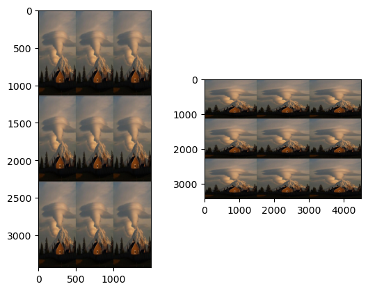

```python
reimg0 = np.repeat(vimg, 3, axis=0)# axis=0按行重复，axis=1按列重复
reimg1 = np.repeat(reimg0, 3, axis=1)# axis=0按行重复，axis=1按列重复
plt.subplot(121)
plt.imshow(reimg0)
plt.subplot(122)
plt.imshow(reimg1)
```

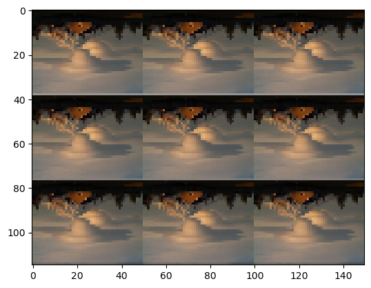

```python
# 7. （数组维度调换）将图片数组做上下颠倒、左右颠倒变换，并展示对应图片
plt.imshow(reimg1[::-30, ::-30, :], cmap='gray')  # 不长越大，图像越模糊
```

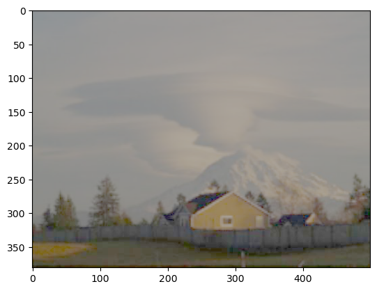

```python
# 8. （数组计算）将图片变亮，可以通过对数变换实现，根据公式：y = b + a*np.log(x+1)去计算，并把计算结果像素大于255的值全部统一为255。
#    其中b为常数，a为系数，x为数组，a,b值可以自己指定。y即为新的数组
# plt.imshow(img, cmap='gray')
y = 10 + 30*np.log(img+1)
y[y >255] = 255 # 大于255的值替换为255
y = np.array(y, dtype=np.int16) # 修改数据类型，画图需要，否则图片很怪
plt.imshow(y)
```

```python
# 9.  （数组保存）把变亮的图片数组保存为.npy文件
np.save(file='./data/img.npy', arr=y)
```

```
(-0.5, 505.5, 386.5, -0.5)
```

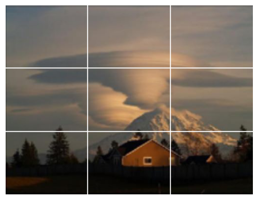

```python
## 10.九宫格图片
img = plt.imread('./data/outdoor.jpg')  # 读取图片

import numpy as np
heigth,width,channel = img.shape
hcut = [int(i) for i in np.linspace(0, heigth, 4)] # 设置高方向的切分点,np.linspace生成等差数列
dcut = [int(i) for i in np.linspace(0, width, 4)] # 设置宽方向的切分点,np.linspace生成等差数列
# 取空白间隔为10
hsetp, dstep = 1,1
# 设置一个初始数组，大小比原图多 间隔*6， 也就是每个图在原图的基础上，左右和上下都添加空白，在行列方向上添加的总和就是6个空白
img2 = np.ones((heigth+hsetp*6, width+dstep*6, channel))*255
# 填充
for k in range(3): # 循环通道
    newimg = []
    for i in range(3): # 循环行
        vimg = []
        for j in range(3): # 循环列
            # 循环截取1/9个，带上通道一起截取，如果只截取高宽，最后三通道的数组组合之后图像可能跟原来不一样
            A = img[hcut[i]: hcut[i+1], dcut[j]: dcut[j+1], k:k+1]
            # 在前后增加分隔的白条， (np.ones((A.shape[0],hsetp,1))*255 表示白色的分隔条
            B = np.hstack((np.ones((A.shape[0],hsetp,1))*255, A, np.ones((A.shape[0],hsetp,1))*255))
            # 在上下增加分隔的白条
            B = np.vstack((np.ones((hsetp,B.shape[1],1))*255, B, np.ones((hsetp,B.shape[1],1))*255))
            vimg.append(B)
        # 将第i行所有列列的图像合并
        vimg = np.hstack((vimg[0], vimg[1], vimg[2]))
        newimg.append(vimg)
    # 将所有行的图像合并
    newimg = np.vstack((newimg[0], newimg[1], newimg[2]))
    img2[:,:,k:k+1] = newimg

img2 = np.array(img2, dtype=np.int16) # 修改数据类型，画图需要，否则图片很怪
plt.imshow(img2)
plt.axis('off')
```

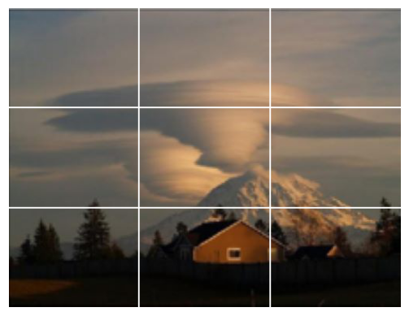

```python
## 10.九宫格图片，把上面的代码整理成函数
import numpy as np
import matplotlib.pyplot as plt

def get_9img(img_path=None, step=5): # img_path,文件路径; step,空白间隔默认为5
    img = plt.imread(img_path)  # 读取图片
    if img.max()==1: # 判断读取到的图片是否为0-1区间，是则变换到0-255区间
        img = img*255
    heigth,width,channel = img.shape
    hcut = [int(i) for i in np.linspace(0, heigth, 4)] # 设置高方向的切分点
    dcut = [int(i) for i in np.linspace(0, width, 4)] # 设置宽方向的切分点
    # 取空白间隔为10
    hsetp, dstep = step,step
    # 设置一个初始数组
    img2 = np.ones((heigth+hsetp*6, width+dstep*6, channel))*255
    # 填充
    for k in range(channel): # 循环通道
        newimg = []
        for i in range(3): # 循环行
            vimg = []
            for j in range(3): # 循环列
                # 循环截取1/9个，带上通道一起截取，如果只截取高宽，最后三通道的数组组合之后图像可能跟原来不一样
                A = img[hcut[i]: hcut[i+1], dcut[j]: dcut[j+1], k:k+1]
                # 在前后增加分隔的白条， (np.ones((A.shape[0],hsetp,1))*255 表示白色的分隔条
                B = np.hstack((np.ones((A.shape[0],hsetp,1))*255, A, np.ones((A.shape[0],hsetp,1))*255))
                # 在上下增加分隔的白条
                B = np.vstack((np.ones((hsetp,B.shape[1],1))*255, B, np.ones((hsetp,B.shape[1],1))*255))
                vimg.append(B)
            # 将第i行所有列列的图像合并
            vimg = np.hstack((vimg[0], vimg[1], vimg[2]))
            newimg.append(vimg)
        # 将所有行的图像合并
        newimg = np.vstack((newimg[0], newimg[1], newimg[2]))
        img2[:,:,k:k+1] = newimg

    img2 = np.array(img2, dtype=np.int16) # 修改数据类型，画图需要，否则图片很怪
    plt.imshow(img2)
    plt.axis('off')


# 调用函数
get_9img('./data/outdoor.jpg', step=1)
```